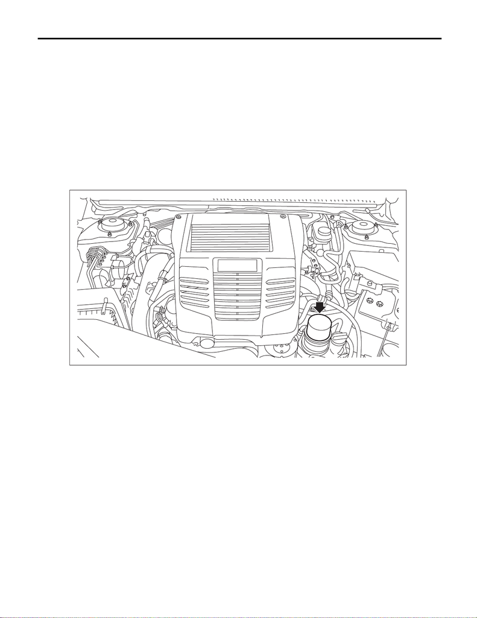

Engine Oil Filter

LUBRICATION

12.Engine Oil Filter

A: REMOVAL

CAUTION:

If the engine oil is spilt over exhaust pipe or the under cover, wipe it off with cloth to avoid emission

of smoke or causing a fire.

Remove the oil filter.

NOTE:

Clean off water or dust from the oil element mating surface using air.

• Oil filter (black)

Remove the oil filter using ST.

ST 498547000 OIL FILTER WRENCH

• Oil filter (blue)

Remove using a general tool (65/67 mm 14 Flutes).

B: INSTALLATION

CAUTION:

Do not tighten excessively, or oil may leak.

1) Clean the oil filter installing surface on the chain cover.

2) Obtain a new oil filter and apply a thin coat of engine oil to the seal rubber.

3) Install the oil filter by turning it by hand, being careful not to damage the seal rubber of the oil filter.

• Further tighten the oil filter (black) with an outer diameter of 80 mm (3.15 in) (approx. 3/4 rotation) after the

seal rubber of the oil filter comes in contact with chain cover. When using a torque wrench, tighten to 14 N·m

(1.4 kgf-m, 10.3 ft-lb).

• Tighten the oil filter (blue) with an outer diameter of 67.4 mm (2.65 in) (approx. 7/8 rotation) after the seal

rubber of the oil filter comes in contact with chain cover. When using a torque wrench, tighten to 12 N·m (1.2

kgf-m, 8.9 ft-lb).

4) After installing, check the engine oil level and replenish it if necessary. <Ref. to LU(w/o STI)-10, INSPEC-

TION, Engine Oil.>

C: INSPECTION

1) After installing the oil filter, run the engine and check for oil leakage.

NOTE:

The filter element and filter case are permanently jointed; therefore, interior cleaning is not necessary.

2) Check the engine oil level. <Ref. to LU(w/o STI)-10, INSPECTION, Engine Oil.>

LU-03203